# A Statistical Analysis of the Likelihood of Heart Disease and the Recommended Medical Tests

Biostatistics II – Final Project

## **Data definitions:**

- age: Age in years
- sex: 1 = Male; 0 = Female
- cp: Chest pain type  
  1 = Typical angina  
  2 = Atypical angina  
  3 = Non-anginal pain  
  4 = Asymptomatic
- trestbps: Resting blood pressure (in mm Hg on admission to the hospital)
- fbs: (Fasting blood sugar > 120 mg/dl) (1 = true; 0 = false)
- restecg: Resting electrocardiographic results 0 = Normal 1 = Having ST-T wave abnormality (T wave inversions and/or ST elevation or depression of > 0.05 mV) 2= Showing probable or definite left ventricular hypertrophy by Estes’ criteria
- thalach: Maximum heart rate achieved
- exang: Exercise induced angina (1 = yes; 0 = no)
- oldpeak: ST depression induced by exercise relative to rest
- slope: Slope of the peak exercise ST segment 1 = upsloping; 2 = flat; 3 = downsloping
- ca: Number of major vessels (0-3) colored by flourosopy
- thal: 3 = normal; 6 = fixed defect; 7 = reversable defect
- diag: 0: No presense of heart disease 1-4: Number of major vessels that > 50% diameter narrowing

## R packages

```r
library(dplyr)
library(ggplot2)
library(readxl)
library(compareGroups)
library(GGally)
library(pROC)
library(kableExtra)
library(nnet)
library(ordinal)

options(scipen=999)
```

# Data Collection and Processing

```r
## original data
US1 <- read_excel("HD.xlsx", sheet = "US1")
US2 <- read_excel("HD.xlsx", sheet = "US2")
EU1 <- read_excel("HD.xlsx", sheet = "EU1")
EU2 <- read_excel("HD.xlsx", sheet = "EU2")
```

```r
## data processing
US1 <- US1 %>% mutate(area = "US1")
US2 <- US2 %>% mutate(area = "US2")
EU1 <- EU1 %>% mutate(area = "EU1")
EU2 <- EU2 %>% mutate(area = "EU2")

# combine all for hospitals
HD <- rbind(US1, US2, EU1, EU2) %>%
    mutate(sex = factor(sex, levels = c(0, 1), labels = c('Female', 'Male')),
           cp = factor(cp, levels = c(1, 2, 3, 4),
                       labels = c('Typical angina', 'Atypical angina', 'Non-anginal pain', 'Asymptomatic')),
           fbs = factor(fbs, levels = c(0, 1), labels = c('False', 'True')),
           restecg = factor(restecg, levels = c(0, 1, 2),
                            labels = c('Normal', 'ST-T Abnormality', 'Left ventricular hypertrophy')),
           exang = factor(exang, levels = c(0, 1), labels = c('No', 'Yes')),
           slope = factor(slope, levels = c(1, 2, 3),
                          labels = c('upsloping', 'flat', 'downsloping')),
           thal = factor(thal, levels = c(3, 6, 7),
                         labels = c('normal', 'fixed defect', 'reversable defect')),
           diag = factor(diag, levels = c(0, 1, 2, 3, 4),
                         labels = c('Diag 0', 'Diag 1', 'Diag 2', 'Diag 3', 'Diag 4')),
           dichotomized_diag = ifelse(diag == 'Diag 0', 'No heart disease', 'Heart disease'))
head(HD)
```

```
## # A tibble: 6 x 15
##     age sex    cp     trestbps fbs   restecg   thalach exang oldpeak slope    ca
##   <dbl> <fct>  <fct>     <dbl> <fct> <fct>       <dbl> <fct>   <dbl> <fct> <dbl>
## 1    63 Male   Typic~      145 True  Left ven~     150 No        2.3 down~     0
## 2    67 Male   Asymp~      160 False Left ven~     108 Yes       1.5 flat      3
## 3    67 Male   Asymp~      120 False Left ven~     129 Yes       2.6 flat      2
## 4    37 Male   Non-a~      130 False Normal        187 No        3.5 down~     0
## 5    41 Female Atypi~      130 False Left ven~     172 No        1.4 upsl~     0
## 6    56 Male   Atypi~      120 False Normal        178 No        0.8 upsl~     0
## # ... with 4 more variables: thal <fct>, diag <fct>, area <chr>,
## #   dichotomized_diag <chr>
```

```r
## check NA
sum(is.na(HD))
```

```
## [1] 0
```

No missing value is found.

```r
library(compareGroups)
library(dplyr)
library(kableExtra)

out <- compareGroups(diag ~ age + trestbps + thalach + oldpeak + ca, data = HD,
                     method = c(1,1,1,1,1),include.label = TRUE, simplify = T, byrow = TRUE)
res <- createTable(out, show.p.overall = T, extra.labels = c("",
"", "", "","", ""))
colnames(res$descr)[6] <- "P-value"
compareGroups::export2md(res, caption = "Table 1. Contingency Table for Patients under Continuous Variables") %>% kable_styling(c("responsive", "condensed", "hover"), fixed_thead = T) %>%
  kable_classic(full_width = F, html_font = "Cambria") %>%
  footnote(general = "Hypothesis Test: t test ")
```

Table 1. Contingency Table for Patients under Continuous Variables

|  | Diag 0 | Diag 1 | Diag 2 | Diag 3 | Diag 4 | P-value |
| --- | --- | --- | --- | --- | --- | --- |
|  | N=411 | N=196 | N=135 | N=135 | N=43 |  |
| age, Mean (SD) | 50.5 (9.43) | 54.5 (9.25) | 56.0 (8.25) | 57.8 (8.09) | 56.2 (8.64) | <0.001 |
| trestbps, Mean (SD) | 130 (16.8) | 130 (19.5) | 134 (18.0) | 137 (22.4) | 142 (21.7) | <0.001 |
| thalach, Mean (SD) | 148 (24.3) | 133 (23.4) | 128 (22.2) | 119 (25.4) | 126 (22.1) | <0.001 |
| oldpeak, Mean (SD) | 0.42 (0.72) | 0.82 (0.98) | 1.30 (1.14) | 1.54 (1.22) | 2.20 (1.30) | <0.001 |
| ca, Mean (SD) | 0.30 (0.67) | 0.74 (0.90) | 1.40 (0.99) | 1.30 (0.99) | 1.70 (1.24) | <0.001 |

Note:  
Hypothesis Test: t test

Some basic statics of continuous variables, including age, trestbps, thalach, oldpeak, and ca, are shown in Table 1. The t test is applied to test if there is any relationship between heart disease and these variables. All p-values less than 0.01 are definitely less than 0.05 significance level. This mean heart disease are associated with these five variables.

```r
out <- compareGroups(diag ~ sex + cp + fbs + restecg + exang + slope + thal + area, data = HD,
                     method = c(3,3,3,3,3,3,3),include.label = TRUE, simplify = T, byrow = TRUE)
res <- createTable(out, show.p.overall = T, extra.labels = c("",
"", "", "","", ""))
colnames(res$descr)[6] <- "P-value"
compareGroups::export2md(res, caption = "Table 2. Contingency Table for Patients under Categorial Variables") %>% kable_styling(c("responsive", "condensed", "hover"), fixed_thead = T) %>%
  kable_classic(full_width = F, html_font = "Cambria") %>%
  footnote(general = "Hypothesis Test: Chi-squared test ")
```

Table 2. Contingency Table for Patients under Categorial Variables

|  | Diag 0 | Diag 1 | Diag 2 | Diag 3 | Diag 4 | P-value |
| --- | --- | --- | --- | --- | --- | --- |
|  | N=411 | N=196 | N=135 | N=135 | N=43 |  |
| sex, N (%): |  |  |  |  |  | <0.001 |
| Female | 144 (74.2%) | 23 (11.9%) | 11 (5.67%) | 11 (5.67%) | 5 (2.58%) |  |
| Male | 267 (36.8%) | 173 (23.8%) | 124 (17.1%) | 124 (17.1%) | 38 (5.23%) |  |
| cp, N (%): |  |  |  |  |  | . |
| Typical angina | 26 (56.5%) | 9 (19.6%) | 5 (10.9%) | 5 (10.9%) | 1 (2.17%) |  |
| Atypical angina | 150 (86.2%) | 14 (8.05%) | 2 (1.15%) | 7 (4.02%) | 1 (0.57%) |  |
| Non-anginal pain | 131 (64.2%) | 31 (15.2%) | 16 (7.84%) | 21 (10.3%) | 5 (2.45%) |  |
| Asymptomatic | 104 (21.0%) | 142 (28.6%) | 112 (22.6%) | 102 (20.6%) | 36 (7.26%) |  |
| fbs, N (%): |  |  |  |  |  | <0.001 |
| False | 367 (47.5%) | 166 (21.5%) | 108 (14.0%) | 94 (12.2%) | 37 (4.79%) |  |
| True | 44 (29.7%) | 30 (20.3%) | 27 (18.2%) | 41 (27.7%) | 6 (4.05%) |  |
| restecg, N (%): |  |  |  |  |  | 0.001 |
| Normal | 268 (48.6%) | 120 (21.7%) | 77 (13.9%) | 69 (12.5%) | 18 (3.26%) |  |
| ST-T Abnormality | 61 (33.9%) | 32 (17.8%) | 36 (20.0%) | 39 (21.7%) | 12 (6.67%) |  |
| Left ventricular hypertrophy | 82 (43.6%) | 44 (23.4%) | 22 (11.7%) | 27 (14.4%) | 13 (6.91%) |  |
| exang, N (%): |  |  |  |  |  | <0.001 |
| No | 350 (63.4%) | 94 (17.0%) | 53 (9.60%) | 42 (7.61%) | 13 (2.36%) |  |
| Yes | 61 (16.6%) | 102 (27.7%) | 82 (22.3%) | 93 (25.3%) | 30 (8.15%) |  |
| slope, N (%): |  |  |  |  |  | . |
| upsloping | 224 (67.3%) | 57 (17.1%) | 26 (7.81%) | 23 (6.91%) | 3 (0.90%) |  |
| flat | 159 (32.9%) | 118 (24.4%) | 87 (18.0%) | 90 (18.6%) | 30 (6.20%) |  |
| downsloping | 28 (27.2%) | 21 (20.4%) | 22 (21.4%) | 22 (21.4%) | 10 (9.71%) |  |
| thal, N (%): |  |  |  |  |  | . |
| normal | 314 (72.2%) | 57 (13.1%) | 31 (7.13%) | 27 (6.21%) | 6 (1.38%) |  |
| fixed defect | 21 (24.7%) | 17 (20.0%) | 27 (31.8%) | 11 (12.9%) | 9 (10.6%) |  |
| reversable defect | 76 (19.0%) | 122 (30.5%) | 77 (19.2%) | 97 (24.2%) | 28 (7.00%) |  |
| area, N (%): |  |  |  |  |  | <0.001 |
| EU1 | 188 (63.9%) | 37 (12.6%) | 26 (8.84%) | 28 (9.52%) | 15 (5.10%) |  |
| EU2 | 8 (6.50%) | 48 (39.0%) | 32 (26.0%) | 30 (24.4%) | 5 (4.07%) |  |
| US1 | 164 (54.1%) | 55 (18.2%) | 36 (11.9%) | 35 (11.6%) | 13 (4.29%) |  |
| US2 | 51 (25.5%) | 56 (28.0%) | 41 (20.5%) | 42 (21.0%) | 10 (5.00%) |  |

Note:  
Hypothesis Test: Chi-squared test

```r
## check the relationship between diag and cp
diag_cp <- table(HD$diag, HD$cp)
diag_cp
```

```
##
##          Typical angina Atypical angina Non-anginal pain Asymptomatic
##   Diag 0             26             150              131          104
##   Diag 1              9              14               31          142
##   Diag 2              5               2               16          112
##   Diag 3              5               7               21          102
##   Diag 4              1               1                5           36
```

```r
chisq.test(diag_cp, correct=FALSE)
```

```
##
##  Pearson's Chi-squared test
##
## data:  diag_cp
## X-squared = 273.13, df = 12, p-value < 0.00000000000000022
```

```r
## check the relationship between diag and slop
diag_slope <- table(HD$diag, HD$slope)
diag_slope
```

```
##
##          upsloping flat downsloping
##   Diag 0       224  159          28
##   Diag 1        57  118          21
##   Diag 2        26   87          22
##   Diag 3        23   90          22
##   Diag 4         3   30          10
```

```r
chisq.test(diag_slope, correct=FALSE)
```

```
##
##  Pearson's Chi-squared test
##
## data:  diag_slope
## X-squared = 122.64, df = 8, p-value < 0.00000000000000022
```

```r
## check the relationship between giag and thal
diag_thal <- table(HD$diag, HD$thal)
diag_thal
```

```
##
##          normal fixed defect reversable defect
##   Diag 0    314           21                76
##   Diag 1     57           17               122
##   Diag 2     31           27                77
##   Diag 3     27           11                97
##   Diag 4      6            9                28
```

```r
chisq.test(diag_thal, correct=FALSE)
```

```
##
##  Pearson's Chi-squared test
##
## data:  diag_thal
## X-squared = 277.01, df = 8, p-value < 0.00000000000000022
```

Those basic statics of categorical variables, including sex, fbs, restecg, exang, region, cp, slope, and thal, are shown in Table 2. The Chi-squared test test is applied to test if there is any relationship between heart disease and these variables. All p-values less than or equal to 0.01 are definitely less than 0.05 significance level. This mean heart disease are associated with these categorical variables.

By dichotomizing the severity variable and considering the presence of narrowing vessel as response variable. We do the same step as above for both continuous and categorial variables.

```r
out <- compareGroups(dichotomized_diag ~ age + trestbps + thalach + oldpeak + ca, data = HD,
                     method = c(1,1,1,1,1),include.label = TRUE, simplify = T, byrow = TRUE)
res <- createTable(out, show.p.overall = T, extra.labels = c("",
"", ""))
colnames(res$descr)[3] <- "P-value"
compareGroups::export2md(res, caption = "Table 3. Contingency Table for Patients under Continuous Variables") %>% kable_styling(c("responsive", "condensed", "hover"), fixed_thead = T) %>%
  kable_classic(full_width = F, html_font = "Cambria") %>%
  footnote(general = "Hypothesis Test: t test ")
```

Table 3. Contingency Table for Patients under Continuous Variables

|  | Heart disease | No heart disease | P-value |
| --- | --- | --- | --- |
|  | N=509 | N=411 |  |
| age, Mean (SD) | 55.9 (8.72) | 50.5 (9.43) | <0.001 |
| trestbps, Mean (SD) | 134 (20.5) | 130 (16.8) | 0.001 |
| thalach, Mean (SD) | 127 (24.1) | 148 (24.3) | <0.001 |
| oldpeak, Mean (SD) | 1.26 (1.19) | 0.42 (0.72) | <0.001 |
| ca, Mean (SD) | 1.15 (1.04) | 0.30 (0.67) | <0.001 |

Note:  
Hypothesis Test: t test

```r
out <- compareGroups(dichotomized_diag ~ sex + cp + fbs + restecg + exang + slope + thal + area, data = HD,
                     method = c(3,3,3,3,3,3,3),include.label = TRUE, simplify = T, byrow = TRUE)
res <- createTable(out, show.p.overall = T, extra.labels = c("",
"", ""))
colnames(res$descr)[3] <- "P-value"
compareGroups::export2md(res, caption = "Table 4. Contingency Table for Patients under Categorial Variables") %>% kable_styling(c("responsive", "condensed", "hover"), fixed_thead = T) %>%
  kable_classic(full_width = F, html_font = "Cambria") %>%
  footnote(general = "Hypothesis Test: Chi-squared test ")
```

Table 4. Contingency Table for Patients under Categorial Variables

|  | Heart disease | No heart disease | P-value |
| --- | --- | --- | --- |
|  | N=509 | N=411 |  |
| sex, N (%): |  |  | <0.001 |
| Female | 50 (25.8%) | 144 (74.2%) |  |
| Male | 459 (63.2%) | 267 (36.8%) |  |
| cp, N (%): |  |  | <0.001 |
| Typical angina | 20 (43.5%) | 26 (56.5%) |  |
| Atypical angina | 24 (13.8%) | 150 (86.2%) |  |
| Non-anginal pain | 73 (35.8%) | 131 (64.2%) |  |
| Asymptomatic | 392 (79.0%) | 104 (21.0%) |  |
| fbs, N (%): |  |  | <0.001 |
| False | 405 (52.5%) | 367 (47.5%) |  |
| True | 104 (70.3%) | 44 (29.7%) |  |
| restecg, N (%): |  |  | 0.003 |
| Normal | 284 (51.4%) | 268 (48.6%) |  |
| ST-T Abnormality | 119 (66.1%) | 61 (33.9%) |  |
| Left ventricular hypertrophy | 106 (56.4%) | 82 (43.6%) |  |
| exang, N (%): |  |  | <0.001 |
| No | 202 (36.6%) | 350 (63.4%) |  |
| Yes | 307 (83.4%) | 61 (16.6%) |  |
| slope, N (%): |  |  | <0.001 |
| upsloping | 109 (32.7%) | 224 (67.3%) |  |
| flat | 325 (67.1%) | 159 (32.9%) |  |
| downsloping | 75 (72.8%) | 28 (27.2%) |  |
| thal, N (%): |  |  | <0.001 |
| normal | 121 (27.8%) | 314 (72.2%) |  |
| fixed defect | 64 (75.3%) | 21 (24.7%) |  |
| reversable defect | 324 (81.0%) | 76 (19.0%) |  |
| area, N (%): |  |  | <0.001 |
| EU1 | 106 (36.1%) | 188 (63.9%) |  |
| EU2 | 115 (93.5%) | 8 (6.50%) |  |
| US1 | 139 (45.9%) | 164 (54.1%) |  |
| US2 | 149 (74.5%) | 51 (25.5%) |  |

Note:  
Hypothesis Test: Chi-squared test

In terms of the dichotomized presence of heart disease, two contingency tables above show that all these 13 continuous and categorial variables are associated with heart diseases as all p-values are less than 0.05 significance level.

Before the further analysis on the association between the heart diseases and the variables, colinearity needs to be checked to determine if there is relationship between those factors of interest except age and sex.

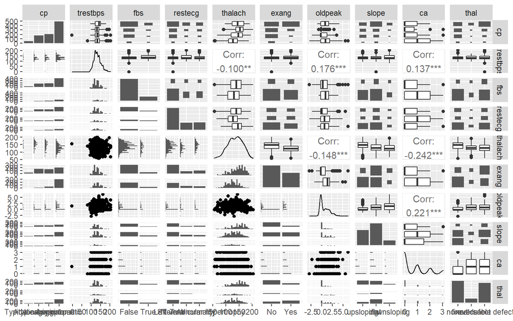

```r
ggpairs(select(HD, cp, trestbps, fbs, restecg, thalach, exang, oldpeak, slope, ca, thal))
```

Correlations are small indicating no colinearity between factors of interest. We can continue the statistical analysis and modeling based on these independent variables.

# Bivariate Relationship Analysis

```r
## logit model for bivaribles
HD <- HD %>% mutate(dichotomized_diag = ifelse(diag == 'Diag 0', 0, 1))
# age
logit_age <- glm(dichotomized_diag ~ age, data = HD, family = "binomial")
coef_age <- round(exp(cbind(OR = coef(logit_age), confint(logit_age))), 2)

# sex
logit_sex <- glm(dichotomized_diag ~ sex, data = HD, family = "binomial")
coef_sex <- round(exp(cbind(OR = coef(logit_sex), confint(logit_sex))), 2)

# cp
logit_cp <- glm(dichotomized_diag ~ cp, data = HD, family = "binomial")
coef_cp <- round(exp(cbind(OR = coef(logit_cp), confint(logit_cp))), 2)

# trestbps
logit_trestbps <- glm(dichotomized_diag ~ trestbps, data = HD, family = "binomial")
coef_trestbps <- round(exp(cbind(OR = coef(logit_trestbps), confint(logit_trestbps))), 2)

# fbs
logit_fbs <- glm(dichotomized_diag ~ fbs, data = HD, family = "binomial")
coef_fbs <- round(exp(cbind(OR = coef(logit_fbs), confint(logit_fbs))), 2)

# restecg
logit_restecg <- glm(dichotomized_diag ~ restecg, data = HD, family = "binomial")
coef_restecg <- round(exp(cbind(OR = coef(logit_restecg), confint(logit_restecg))), 2)

# thalach
logit_thalach <- glm(dichotomized_diag ~ thalach, data = HD, family = "binomial")
coef_thalach <- round(exp(cbind(OR = coef(logit_thalach), confint(logit_thalach))), 2)

# exang
logit_exang <- glm(dichotomized_diag ~ exang, data = HD, family = "binomial")
coef_exang <- round(exp(cbind(OR = coef(logit_exang), confint(logit_exang))), 2)

# oldpeak
logit_oldpeak <- glm(dichotomized_diag ~ oldpeak, data = HD, family = "binomial")
coef_oldpeak <- round(exp(cbind(OR = coef(logit_oldpeak), confint(logit_oldpeak))), 2)

# slope
logit_slope <- glm(dichotomized_diag ~ slope, data = HD, family = "binomial")
coef_slope <- round(exp(cbind(OR = coef(logit_slope), confint(logit_slope))), 2)

# ca
logit_ca <- glm(dichotomized_diag ~ ca, data = HD, family = "binomial")
coef_ca <- round(exp(cbind(OR = coef(logit_ca), confint(logit_ca))), 2)

# thal
logit_thal <- glm(dichotomized_diag ~ thal, data = HD, family = "binomial")
coef_thal <- round(exp(cbind(OR = coef(logit_thal), confint(logit_thal))), 2)

# area
logit_area <- glm(dichotomized_diag ~ area, data = HD, family = "binomial")
coef_area <- round(exp(cbind(OR = coef(logit_area), confint(logit_area))), 2)

# combine the coefficients and CIs
coefs <- as.data.frame(rbind(coef_age[2,], coef_sex[2,], coef_cp[2:4,], coef_trestbps[2,],
                             coef_fbs[2,], coef_restecg[2:3,], coef_thalach[2,], coef_exang[2,],
                             coef_oldpeak[2,], coef_slope[2:3,], coef_ca[2,], coef_thal[2:3,], coef_area[2:4,]))
rownames(coefs) <- c('age', 'sex: Male', 'cp: Atypical angina', 'cp: Non-anginal pain', 'cp: Asymptomatic',
                     'trestbps', 'fbs: True', 'restecg: ST-T Abnormality', 'restecg: Left ventricular hypertrophy',
                     'thalach', 'exang: Yes', 'oldpeak', 'slope: flat',
                     'slope: downsloping', 'ca', 'thal: fixed defect', 'thal: reversable defect',
                     'area: EU2', 'area: US1', 'area: US2')
coefs <- coefs %>%
    mutate(`95%CI` = paste0('(', `2.5 %`, ', ', `97.5 %`, ')')) %>%
    select(OR, `95%CI`)
colnames(coefs) <- c('Unadjusted OR', '95% Confidence Interval')
coefs %>% kable(align = 'c', caption = 'Table . Unadjusted OR for presence of heart disease') %>% kable_classic(full_width = F, html_font = "Cambria")
```

Table . Unadjusted OR for presence of heart disease

|  | Unadjusted OR | 95% Confidence Interval |
| --- | --- | --- |
| age | 1.07 | (1.05, 1.08) |
| sex: Male | 4.95 | (3.49, 7.12) |
| cp: Atypical angina | 0.21 | (0.1, 0.43) |
| cp: Non-anginal pain | 0.72 | (0.38, 1.4) |
| cp: Asymptomatic | 4.90 | (2.64, 9.22) |
| trestbps | 1.01 | (1, 1.02) |
| fbs: True | 2.14 | (1.47, 3.16) |
| restecg: ST-T Abnormality | 1.84 | (1.3, 2.63) |
| restecg: Left ventricular hypertrophy | 1.22 | (0.88, 1.7) |
| thalach | 0.97 | (0.96, 0.97) |
| exang: Yes | 8.72 | (6.34, 12.15) |
| oldpeak | 2.47 | (2.1, 2.92) |
| slope: flat | 4.20 | (3.13, 5.67) |
| slope: downsloping | 5.50 | (3.41, 9.11) |
| ca | 3.18 | (2.63, 3.89) |
| thal: fixed defect | 7.91 | (4.7, 13.79) |
| thal: reversable defect | 11.06 | (8.02, 15.41) |
| area: EU2 | 25.50 | (12.71, 58.65) |
| area: US1 | 1.50 | (1.08, 2.09) |
| area: US2 | 5.18 | (3.5, 7.76) |

```r
# glm model
logit_reg <- glm(dichotomized_diag ~ . - diag, data = HD, family = "binomial")
summary(logit_reg)
```

```
##
## Call:
## glm(formula = dichotomized_diag ~ . - diag, family = "binomial",
##     data = HD)
##
## Deviance Residuals:
##     Min       1Q   Median       3Q      Max
## -3.2984  -0.3991   0.1003   0.3989   2.6415
##
## Coefficients:
##                                      Estimate Std. Error z value
## (Intercept)                         -5.567802   1.496727  -3.720
## age                                  0.018127   0.014215   1.275
## sexMale                              0.948544   0.291426   3.255
## cpAtypical angina                   -0.656317   0.476646  -1.377
## cpNon-anginal pain                  -0.240191   0.429687  -0.559
## cpAsymptomatic                       1.128891   0.417580   2.703
## trestbps                             0.003305   0.005792   0.571
## fbsTrue                              0.244335   0.305180   0.801
## restecgST-T Abnormality              0.063223   0.304880   0.207
## restecgLeft ventricular hypertrophy  0.317965   0.308931   1.029
## thalach                              0.001120   0.005275   0.212
## exangYes                             0.990796   0.246858   4.014
## oldpeak                              0.495948   0.122865   4.037
## slopeflat                            0.815905   0.247058   3.302
## slopedownsloping                     0.267326   0.411443   0.650
## ca                                   0.917939   0.132598   6.923
## thalfixed defect                     1.061469   0.385100   2.756
## thalreversable defect                1.655090   0.231556   7.148
## areaEU2                              2.914735   0.484730   6.013
## areaUS1                              0.022505   0.334124   0.067
## areaUS2                              0.371905   0.363811   1.022
##                                              Pr(>|z|)
## (Intercept)                                  0.000199 ***
## age                                          0.202231
## sexMale                                      0.001135 **
## cpAtypical angina                            0.168528
## cpNon-anginal pain                           0.576168
## cpAsymptomatic                               0.006863 **
## trestbps                                     0.568319
```

[output cut: 9 more lines]

```
## thalfixed defect                             0.005845 **
## thalreversable defect               0.000000000000882 ***
## areaEU2                             0.000000001819924 ***
## areaUS1                                      0.946300
## areaUS2                                      0.306663
## ---
## Signif. codes:  0 '***' 0.001 '**' 0.01 '*' 0.05 '.' 0.1 ' ' 1
##
## (Dispersion parameter for binomial family taken to be 1)
##
##     Null deviance: 1264.93  on 919  degrees of freedom
## Residual deviance:  571.77  on 899  degrees of freedom
## AIC: 613.77
##
## Number of Fisher Scoring iterations: 6
```

```r
## adjusted OR

library("finalfit")
HD <- HD %>% mutate(dichotomized_diag = ifelse(diag == 'Diag 0', 0, 1))

dependent_os <- "dichotomized_diag"
explanatory <- c("sex", "cp","exang","oldpeak", "slope","thal", "area")

caption <- "<h5 style=color:black;text-align:center><b>Table 2. Multiple Cox Proportional Hazards Regression Model of Overall Survival."

HD %>% finalfit(dependent_os, explanatory, add_dependent_label = FALSE) -> t1
knitr::kable(t1, row.names=FALSE, align=c("l", "l", "r", "r", "r", "r"))
```

label

levels

unit

value

Coefficient (univariable)

Coefficient (multivariable)

sex

Female

Mean (sd)

0.3 (0.4)

Male

Mean (sd)

0.6 (0.5)

0.37 (0.30 to 0.45, p<0.001)

0.12 (0.06 to 0.17, p<0.001)

cp

Typical angina

Mean (sd)

0.4 (0.5)

Atypical angina

Mean (sd)

0.1 (0.3)

-0.30 (-0.43 to -0.16, p<0.001)

-0.12 (-0.23 to -0.00, p=0.048)

Non-anginal pain

Mean (sd)

0.4 (0.5)

-0.08 (-0.21 to 0.06, p=0.261)

-0.03 (-0.14 to 0.08, p=0.548)

Asymptomatic

Mean (sd)

0.8 (0.4)

0.36 (0.23 to 0.48, p<0.001)

0.17 (0.06 to 0.28, p=0.002)

exang

No

Mean (sd)

0.4 (0.5)

Yes

Mean (sd)

0.8 (0.4)

0.47 (0.41 to 0.53, p<0.001)

0.14 (0.09 to 0.20, p<0.001)

oldpeak

[-2.6,6.2]

Mean (sd)

0.6 (0.5)

0.17 (0.15 to 0.20, p<0.001)

0.07 (0.05 to 0.09, p<0.001)

slope

upsloping

Mean (sd)

0.3 (0.5)

flat

Mean (sd)

0.7 (0.5)

0.34 (0.28 to 0.41, p<0.001)

0.11 (0.06 to 0.16, p<0.001)

downsloping

Mean (sd)

0.7 (0.4)

0.40 (0.30 to 0.50, p<0.001)

0.03 (-0.06 to 0.11, p=0.521)

thal

normal

Mean (sd)

0.3 (0.4)

fixed defect

Mean (sd)

0.8 (0.4)

0.47 (0.38 to 0.57, p<0.001)

0.22 (0.13 to 0.30, p<0.001)

reversable defect

Mean (sd)

0.8 (0.4)

0.53 (0.47 to 0.59, p<0.001)

0.26 (0.21 to 0.31, p<0.001)

area

EU1

Mean (sd)

0.4 (0.5)

EU2

Mean (sd)

0.9 (0.2)

0.57 (0.48 to 0.67, p<0.001)

0.34 (0.27 to 0.42, p<0.001)

US1

Mean (sd)

0.5 (0.5)

0.10 (0.03 to 0.17, p=0.008)

0.04 (-0.02 to 0.10, p=0.167)

US2

Mean (sd)

0.7 (0.4)

0.38 (0.30 to 0.47, p<0.001)

0.12 (0.05 to 0.19, p=0.001)

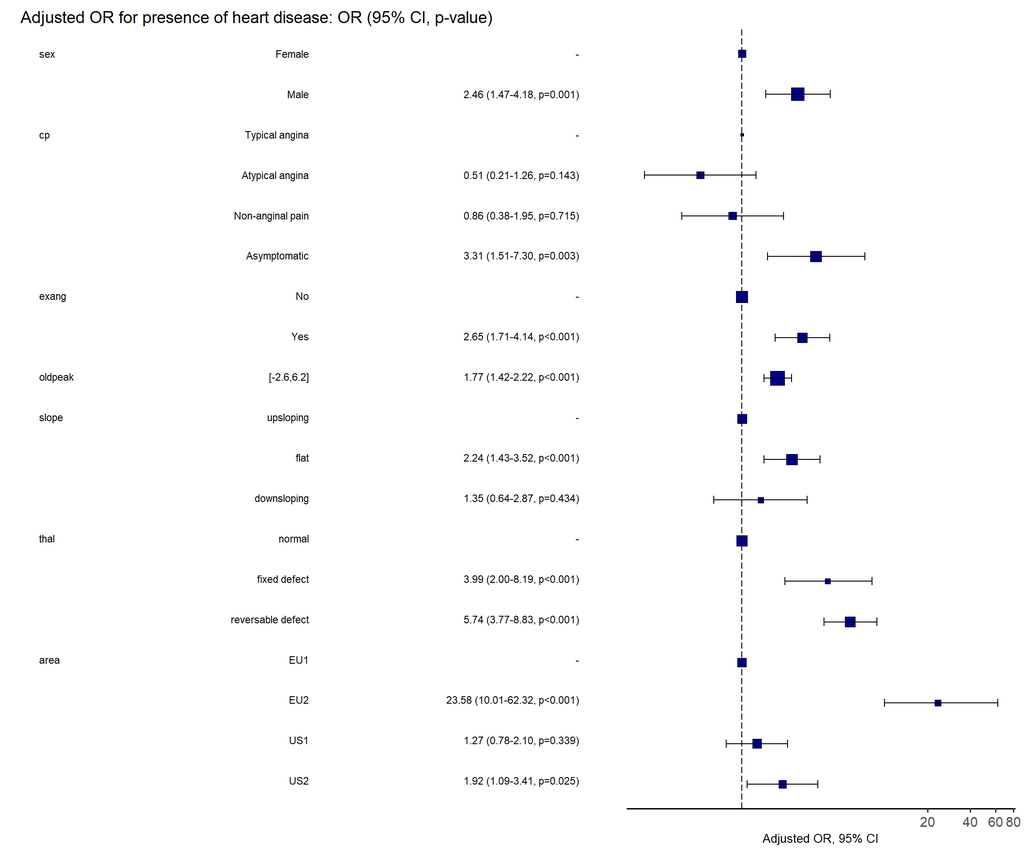

```r
HD %>%
         or_plot(dependent_os, explanatory,dependent_label = "Adjusted OR for presence of heart disease", table_text_size=3, title_text_size=14,
    plot_opts=list(xlab("Adjusted OR, 95% CI"), theme(axis.title = element_text(size=10))))
```

COnsidering the ROC,

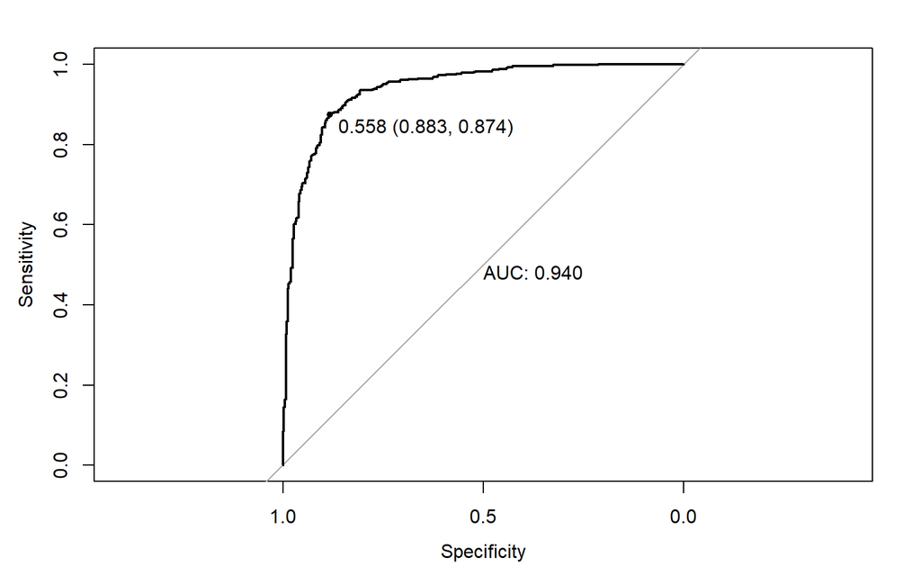

```r
# calculate ROC
roc <- roc(HD$dichotomized_diag, logit_reg$fitted.values, plot = T, print.thres = T, print.auc = T)
```

Both ROC curve (receiver operating characteristic curve) and AUC (area under the ROC curve) are useful in evaluating the performance of the fitting model. The higher value of the upper-right corner value of ROC and the higher the AUC, the better the model is at distinguishing between patients with the disease and no disease. AUC equal to 0.94 in the above plot indicates the model works well.

# CLM

We consider Cumulative Link Models for Ordinal Regression for analyzing the disease due to the order of the outcome variable.

```r
clm_all <- clm(diag ~ . - dichotomized_diag, data = HD)
summary(clm_all)
```

```
## formula:
## diag ~ (age + sex + cp + trestbps + fbs + restecg + thalach + exang + oldpeak + slope + ca + thal + area + dichotomized_diag) - dichotomized_diag
## data:    HD
##
##  link  threshold nobs logLik  AIC     niter max.grad cond.H
##  logit flexible  920  -917.74 1883.48 6(0)  1.04e-11 3.0e+07
##
## Coefficients:
##                                      Estimate Std. Error z value
## age                                  0.009975   0.009309   1.072
## sexMale                              0.898661   0.216580   4.149
## cpAtypical angina                   -0.970434   0.404108  -2.401
## cpNon-anginal pain                  -0.244194   0.357190  -0.684
## cpAsymptomatic                       0.471360   0.341193   1.382
## trestbps                             0.004868   0.003875   1.256
## fbsTrue                              0.293448   0.185710   1.580
## restecgST-T Abnormality              0.449666   0.189183   2.377
## restecgLeft ventricular hypertrophy  0.231601   0.208996   1.108
## thalach                             -0.008647   0.003360  -2.574
## exangYes                             0.612960   0.164529   3.726
## oldpeak                              0.535937   0.072680   7.374
## slopeflat                            0.559773   0.169775   3.297
## slopedownsloping                     0.474300   0.252690   1.877
## ca                                   0.699501   0.075270   9.293
## thalfixed defect                     0.901862   0.243407   3.705
## thalreversable defect                1.016351   0.167200   6.079
## areaEU2                              0.935931   0.236533   3.957
## areaUS1                              0.031654   0.235664   0.134
## areaUS2                             -0.176666   0.238692  -0.740
##                                                 Pr(>|z|)
## age                                             0.283915
## sexMale                                0.000033345012229 ***
## cpAtypical angina                               0.016331 *
## cpNon-anginal pain                              0.494195
## cpAsymptomatic                                  0.167124
## trestbps                                        0.209076
## fbsTrue                                         0.114074
## restecgST-T Abnormality                         0.017460 *
## restecgLeft ventricular hypertrophy             0.267793
## thalach                                         0.010058 *
## exangYes                                        0.000195 ***
## oldpeak                                0.000000000000166 ***
## slopeflat                                       0.000977 ***
## slopedownsloping                                0.060518 .
## ca                                  < 0.0000000000000002 ***
## thalfixed defect                                0.000211 ***
## thalreversable defect                  0.000000001212025 ***
## areaEU2                                0.000075937045927 ***
## areaUS1                                         0.893151
## areaUS2                                         0.459214
## ---
## Signif. codes:  0 '***' 0.001 '**' 0.01 '*' 0.05 '.' 0.1 ' ' 1
##
## Threshold coefficients:
##               Estimate Std. Error z value
## Diag 0|Diag 1   2.7452     0.9554   2.873
## Diag 1|Diag 2   4.5295     0.9643   4.697
## Diag 2|Diag 3   5.7576     0.9707   5.931
## Diag 3|Diag 4   7.8130     0.9882   7.906
```

The model shows the the heart disease is irrelevant with age (0.284), trestbps (0.210), and fbs (0.114) as their p-values are larger than 0.05. We update the model by excluding these variables.

```r
# update model
clm_update <- clm(diag ~ sex + cp + restecg + thalach + exang + oldpeak + slope + ca + thal + area, data = HD)
summary(clm_update)
```

```
## formula:
## diag ~ sex + cp + restecg + thalach + exang + oldpeak + slope + ca + thal + area
## data:    HD
##
##  link  threshold nobs logLik  AIC     niter max.grad cond.H
##  logit flexible  920  -921.18 1884.37 6(0)  2.54e-12 6.8e+06
##
## Coefficients:
##                                      Estimate Std. Error z value
## sexMale                              0.864239   0.215214   4.016
## cpAtypical angina                   -0.968247   0.403640  -2.399
## cpNon-anginal pain                  -0.264284   0.357113  -0.740
## cpAsymptomatic                       0.437161   0.340485   1.284
## restecgST-T Abnormality              0.522092   0.187081   2.791
## restecgLeft ventricular hypertrophy  0.295613   0.207421   1.425
## thalach                             -0.009953   0.003252  -3.060
## exangYes                             0.607622   0.163386   3.719
## oldpeak                              0.549530   0.071942   7.639
## slopeflat                            0.579666   0.169502   3.420
## slopedownsloping                     0.487867   0.252200   1.934
## ca                                   0.721810   0.074654   9.669
## thalfixed defect                     0.936799   0.242272   3.867
## thalreversable defect                1.037221   0.167002   6.211
## areaEU2                              0.965432   0.229066   4.215
## areaUS1                              0.107885   0.225382   0.479
## areaUS2                             -0.048358   0.218504  -0.221
##                                                 Pr(>|z|)
## sexMale                                0.000059266971161 ***
## cpAtypical angina                               0.016449 *
## cpNon-anginal pain                              0.459265
## cpAsymptomatic                                  0.199164
## restecgST-T Abnormality                         0.005259 **
## restecgLeft ventricular hypertrophy             0.154103
## thalach                                         0.002211 **
## exangYes                                        0.000200 ***
## oldpeak                                0.000000000000022 ***
## slopeflat                                       0.000627 ***
## slopedownsloping                                0.053059 .
## ca                                  < 0.0000000000000002 ***
## thalfixed defect                                0.000110 ***
## thalreversable defect                  0.000000000527110 ***
## areaEU2                                0.000025016525849 ***
## areaUS1                                         0.632169
## areaUS2                                         0.824847
## ---
## Signif. codes:  0 '***' 0.001 '**' 0.01 '*' 0.05 '.' 0.1 ' ' 1
##
## Threshold coefficients:
##               Estimate Std. Error z value
## Diag 0|Diag 1   1.4319     0.6469   2.213
## Diag 1|Diag 2   3.2067     0.6569   4.881
## Diag 2|Diag 3   4.4226     0.6622   6.679
## Diag 3|Diag 4   6.4608     0.6819   9.475
```

Even though the updates model shows the validation, we need to check if every factor of interest meet the PH assumptions.

```r
nominal_test(clm_update)
```

```
## Tests of nominal effects
##
## formula: diag ~ sex + cp + restecg + thalach + exang + oldpeak + slope + ca + thal + area
##         Df  logLik    AIC    LRT   Pr(>Chi)
## <none>     -921.18 1884.4
## sex      3 -919.47 1886.9  3.427  0.3302877
## cp       9 -905.96 1871.9 30.459  0.0003664 ***
## restecg  6 -916.34 1886.7  9.692  0.1382572
## thalach  3 -918.17 1884.3  6.031  0.1101059
## exang    3 -918.36 1884.7  5.643  0.1303200
## oldpeak  3 -919.53 1887.1  3.299  0.3477450
## slope    6 -919.96 1893.9  2.456  0.8733830
## ca       3 -913.22 1874.5 15.922  0.0011768 **
## thal     6 -905.78 1865.6 30.808 0.00002758 ***
## area     9 -902.16 1864.3 38.042 0.00001713 ***
## ---
## Signif. codes:  0 '***' 0.001 '**' 0.01 '*' 0.05 '.' 0.1 ' ' 1
```

The test shows that sex, restecg, thalach, exang, oldpeak and slope satisfy the PH assumptions as their p-values are greater than 0.05 significance level. However, variables including cp, thal, ca and area do not satisfy the PH assumptions as their p-values are less than 0.05 significance level. Then, we only take variables sex, restecg, thalach, exang, oldpeak and slope in to consideration for updating the model.

```r
clm_latest <- clm(diag ~ sex + restecg + thalach + exang + oldpeak + slope, data = HD)
summary(clm_latest)
```

```
## formula: diag ~ sex + restecg + thalach + exang + oldpeak + slope
## data:    HD
##
##  link  threshold nobs logLik   AIC     niter max.grad cond.H
##  logit flexible  920  -1052.35 2128.70 6(0)  4.31e-12 3.8e+06
##
## Coefficients:
##                                      Estimate Std. Error z value
## sexMale                              1.171669   0.193461   6.056
## restecgST-T Abnormality              0.434536   0.167516   2.594
## restecgLeft ventricular hypertrophy  0.302376   0.172697   1.751
## thalach                             -0.020896   0.002895  -7.217
## exangYes                             0.870580   0.148772   5.852
## oldpeak                              0.643250   0.067235   9.567
## slopeflat                            0.617220   0.159101   3.879
## slopedownsloping                     0.426005   0.236294   1.803
##                                                 Pr(>|z|)
## sexMale                                0.000000001392406 ***
## restecgST-T Abnormality                         0.009487 **
## restecgLeft ventricular hypertrophy             0.079962 .
## thalach                                0.000000000000532 ***
## exangYes                               0.000000004863777 ***
## oldpeak                             < 0.0000000000000002 ***
## slopeflat                                       0.000105 ***
## slopedownsloping                                0.071411 .
## ---
## Signif. codes:  0 '***' 0.001 '**' 0.01 '*' 0.05 '.' 0.1 ' ' 1
##
## Threshold coefficients:
##               Estimate Std. Error z value
## Diag 0|Diag 1  -0.8114     0.4784  -1.696
## Diag 1|Diag 2   0.5289     0.4781   1.106
## Diag 2|Diag 3   1.5863     0.4790   3.312
## Diag 3|Diag 4   3.4800     0.4973   6.998
```

We want to guarantee the difference between the first updated and the second updated model by checking ANOVA.

```r
anova(clm_update, clm_latest)
```

```
## Likelihood ratio tests of cumulative link models:
##
##            formula:
## clm_latest diag ~ sex + restecg + thalach + exang + oldpeak + slope
## clm_update diag ~ sex + cp + restecg + thalach + exang + oldpeak + slope + ca + thal + area
##            link: threshold:
## clm_latest logit flexible
## clm_update logit flexible
##
##            no.par    AIC   logLik LR.stat df            Pr(>Chisq)
## clm_latest     12 2128.7 -1052.35
## clm_update     21 1884.4  -921.18  262.33  9 < 0.00000000000000022 ***
## ---
## Signif. codes:  0 '***' 0.001 '**' 0.01 '*' 0.05 '.' 0.1 ' ' 1
```

```r
clm_OR <- coef(clm_latest) %>% as.data.frame() %>% exp() %>% round(2)
clm_CI <- confint(clm_latest) %>% as.data.frame() %>% exp() %>% round(2)
clm_adjusted_table <- cbind(clm_OR[5:nrow(clm_OR),], clm_CI)
colnames(clm_adjusted_table) <- c('Adjusted OR', '2.5 %', '97.5 %')
clm_adjusted_table <- clm_adjusted_table %>%
    mutate(`95% CI` = paste0('(', `2.5 %`, ', ', `97.5 %`, ')')) %>%
    select(`Adjusted OR`, `95% CI`)
clm_adjusted_table %>% kable(align = 'c', caption = 'Table. Adjusted OR and CI of Cumulative Model') %>% kable_classic(full_width = F, html_font = "Cambria")
```

Table. Adjusted OR and CI of Cumulative Model

|  | Adjusted OR | 95% CI |
| --- | --- | --- |
| sexMale | 3.23 | (2.22, 4.75) |
| restecgST-T Abnormality | 1.54 | (1.11, 2.14) |
| restecgLeft ventricular hypertrophy | 1.35 | (0.96, 1.9) |
| thalach | 0.98 | (0.97, 0.98) |
| exangYes | 2.39 | (1.78, 3.2) |
| oldpeak | 1.90 | (1.67, 2.17) |
| slopeflat | 1.85 | (1.36, 2.54) |
| slopedownsloping | 1.53 | (0.96, 2.43) |